# Bayesian separable temporal ERGMs for binary and signed networks

**Bstergm** fits Bayesian separable temporal ERGMs to sequences of binary networks, with `bstergm()`, and of signed networks, with `bstergm_sign()`. This vignette analyses the U.S. Senate data of Caimo and Gollini (2025): the signs with `bstergm_sign()` and the interactions, a sequence of binary networks, with `bstergm()`.

## The model

A signed network $y_t$ on $n$ nodes has ties $y_{ij,t} \in \{-1, 0, +1\}$. It is written as an *interaction* layer $x_t$ ($x_{ij,t} = |y_{ij,t}|$) and a *sign* layer $z_t$ ($z_{ij,t} = 1$ if $y_{ij,t} = +1$), which is only defined for interacting pairs.

As in the separable temporal ERGM of Krivitsky and Handcock (2014), each transition $y_{t-1} \to y_t$ is split into a *formation* network $y^F_t = y_{t-1} \cup y_t$ and a *persistence* network $y^P_t = y_{t-1} \cap y_t$, for both layers. The model is
$$p(y_t \mid y_{t-1}) =
\prod_{U \in \{F, P\}} p(x^U_t \mid y_{t-1}; \xi^U)\; p(z^U_t \mid
x^U_t, y_{t-1}; \zeta^U),$$
where every factor is an ERGM. The sign model $p(z^U_t \mid x^U_t, \cdot\,; \zeta^U)$ lets the sign of every interacting dyad of $x^U_t$ vary while the interactions stay fixed. Its log-odds of a positive sign are $\zeta^{U\top} \Delta_{ij} s(z^U_t; x^U_t, y_{t-1})$. Under independent priors the posterior factorises into four independent parts: $\zeta^F$, $\zeta^P$, $\xi^F$ and $\xi^P$.

## Data

`senators70_am` contains the signed co-sponsorship networks of the 70 senators who served in the 99th to 102nd Congress (Neal, 2020). As in the paper, we use the first three Congresses (1985–1991).

```r
library(Bstergm)
data(senators70_am)

senate <- signed_series(senators70_am[1:3],
                        vertex.attr = attr(senators70_am$S99, "senators"))
senate
```

```
#> Sequence of 3 undirected signed networks on 70 nodes
#>  time positive negative active density %positive
#>   S99      284      747   1031   0.427      27.5
#>  S100      234      808   1042   0.431      22.5
#>  S101      363      810   1173   0.486      30.9
#> Vertex attributes: ID, Senator, State, Party
```

`summary()` shows the formation and persistence networks of each transition and the signed triangle census. Balance theory says that triangles with one or three positive ties (`+++`, `+--`) should be common and those with two (`++-`) rare.

```r
summary(senate)
```

```
#> Ties by time point:
#>  time positive negative active density %positive
#>   S99      284      747   1031   0.427      27.5
#>  S100      234      808   1042   0.431      22.5
#>  S101      363      810   1173   0.486      30.9
#>
#> Formation (F) and persistence (P) networks by transition:
#>    transition F.active F.positive P.active P.positive
#>   S99 -> S100     1442        380      631        138
#>  S100 -> S101     1472        441      743        156
#>
#> Signed triangles by time point:
#>       +++ ++-  +--  ---
#> S99   644 105 2753 2066
#> S100  384  88 2171 3200
#> S101 1119 114 3521 3193
```

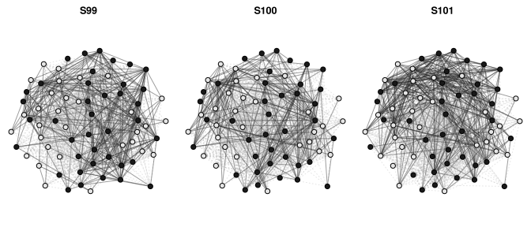

```r
plot(senate, vertex.col = "Party")
```

Dark solid lines are positive ties and light dotted lines negative ties; Democrats are dark and Republicans light grey.

## Signed-network statistics

The sign process is modelled on the *positive* ties of each formation or persistence network. The interacting pairs are fixed and stored with the network, so negative ties are the interacting pairs that are not positive. `as_signed_network()` builds this representation for a single network. Any ergm term then describes positive ties, and the signed terms of the package also use the negative ties:

```r
nw <- as_signed_network(senators70_am$S99,
                        vertex.attr = attr(senators70_am$S99, "senators"))
summary(nw ~ edges + nodematch("Party", diff = TRUE, levels = "R") +
          gwesf_pos(0.6) + gwese_pos(0.6) + gwese_neg(0.6) + triangle_signed())
```

```
#>               edges   nodematch.Party.R gwesf_pos.fixed.0.6 gwese_pos.fixed.0.6
#>            284.0000             36.0000            451.0102            495.2528
#> gwese_neg.fixed.0.6  triangle_signed+++  triangle_signed++-  triangle_signed+--
#>           1258.0762            644.0000            105.0000           2753.0000
#>  triangle_signed---
#>           2066.0000
```

| paper | term | description |
| --- | --- | --- |
| $\text{edges}^+$ | `edges` | number of positive ties |
| $\text{homophily}^+(\text{rep})$ | `nodematch("Party", diff = TRUE, levels = "R")` | positive ties between Republicans |
| $\text{gwdegree}^+(0.2)$ | `gwdegree(0.2, fixed = TRUE)` | geometrically weighted positive degree |
| $\text{gwesf}^+(0.6)$ | `gwesf_pos(0.6)` | positive ties weighted by shared friends |
| $\text{gwese}^+(0.6)$ | `gwese_pos(0.6)` | positive ties weighted by shared enemies |
| $\text{gwese}^-(0.6)$ | `gwese_neg(0.6)` | negative ties weighted by shared enemies |

These terms are implemented in C. They give the same values as the multilayer terms of **ergm.multi** used in the first version of the package, which are still supported but considerably slower:

```r
positive <- ~positive
negative <- ~(active & !positive)
z <- network::as.network((senators70_am$S99 > 0) * 1, directed = FALSE)
x <- network::as.network((senators70_am$S99 != 0) * 1, directed = FALSE)
summary(~ gwespL(0.6, fixed = TRUE, L.base = positive, Ls.path = list(positive, positive)) +
          gwespL(0.6, fixed = TRUE, L.base = positive, Ls.path = list(negative, negative)) +
          gwespL(0.6, fixed = TRUE, L.base = negative, Ls.path = list(negative, negative)),
        basis = Layer(positive = z, active = x))
```

```
#>                     L(pth=(positive),bse=positive,inord=FALSE)~gwesp.fixed.0.6
#>                                                                       451.0102
#>           L(pth=((active&!positive)),bse=positive,inord=FALSE)~gwesp.fixed.0.6
#>                                                                       495.2528
#> L(pth=((active&!positive)),bse=(active&!positive),inord=FALSE)~gwesp.fixed.0.6
#>                                                                      1258.0762
```

## Posterior sampling

`bstergm_sign()` samples the posterior of the formation and persistence parameters of the sign process with the approximate exchange algorithm. By default it uses adaptive Metropolis-Hastings. The two components are independent and run in parallel with `cores`, as do several chains. A short run looks like this:

```r
f <- ~ edges + nodematch("Party", diff = TRUE, levels = "R") +
  gwdegree(0.2, fixed = TRUE) + gwesf_pos(0.6) + gwese_pos(0.6) + gwese_neg(0.6)

quick <- bstergm_sign(f, data = senate, iters = 300, burn.in = 100, seed = 1, verbose = FALSE)
quick
```

```
#> Bayesian separable temporal ERGM for signed networks
#>   process: sign | method: AMH | engine: native
#>   formula: ~edges + nodematch("Party", diff = TRUE, levels = "R") + gwdegree(0.2, fixed = TRUE) + gwesf_pos(0.6) + gwese_pos(0.6) + gwese_neg(0.6)
#>   transitions: 2 | iterations: 300 | burn-in: 100 | thin: 1
#>
#> Formation (F) - sign process: 1 chain, acceptance 0.05
#>                       Mean    SD
#> edges               -8.564 0.757
#> nodematch.Party.R    0.550 0.062
#> gwdeg.fixed.0.2     -0.296 0.445
#> gwesf_pos.fixed.0.6  2.251 0.152
#> gwese_pos.fixed.0.6  0.252 0.448
#> gwese_neg.fixed.0.6 -1.478 0.198
#>
#> Persistence (P) - sign process: 1 chain, acceptance 0.08
#>                       Mean    SD
#> edges               -3.703 0.101
#> nodematch.Party.R    0.697 0.222
#> gwdeg.fixed.0.2      0.489 0.295
#> gwesf_pos.fixed.0.6  1.315 0.105
#> gwese_pos.fixed.0.6 -0.508 0.102
#> gwese_neg.fixed.0.6 -0.389 0.034
```

Each iteration runs one auxiliary network simulation per transition and component, started at the observed network. Their length is set by default to three proposals per free dyad (see `control.bstergm()`). Chains start at a pooled maximum pseudo-likelihood estimate, which also gives the initial proposal covariance; `init = "ads"` instead runs adaptive direction sampling first, the scheme used by Caimo and Gollini. Results are reproducible with `seed`, whatever the number of cores.

The analysis below used two chains of 35,000 iterations, with a 10,000 iteration burn-in and the priors of the paper: $N(-1, 25)$ for the edges parameter and $N(0, 25)$ for the others. It took 19 minutes on two cores; on the same machine, version 0.1 of the package would have needed about 3 days. The result is shipped with the package:

```r
fit <- bstergm_sign(f, data = senate, iters = 35000, burn.in = 10000, thin = 25,
                    n_chains = 2, cores = 2, seed = 2025,
                    prior.mean = c(-1, 0, 0, 0, 0, 0), prior.sigma = 25)
```

```r
fit <- readRDS(system.file("extdata", "senate_fit.rds", package = "Bstergm"))
```

```r
summary(fit)
```

```
#> Posterior summary (AMH, 35000 iterations, 10000 burn-in, thin 25)
#>
#> Formation (F) - sign process
#>   chains: 2 | acceptance: 0.106 0.107
#>                        Mean    SD Naive SE Time-series SE    2.5%     50%
#> edges               -10.387 1.739    0.039          0.066 -14.124 -10.276
#> nodematch.Party.R     0.433 0.133    0.003          0.005   0.179   0.428
#> gwdeg.fixed.0.2       0.487 0.745    0.017          0.027  -1.027   0.508
#> gwesf_pos.fixed.0.6   2.612 0.277    0.006          0.009   2.061   2.622
#> gwese_pos.fixed.0.6   0.864 0.861    0.019          0.032  -0.553   0.757
#> gwese_neg.fixed.0.6  -1.522 0.190    0.004          0.006  -1.871  -1.531
#>                      97.5%      ESS  Rhat
#> edges               -7.414  702.296 1.000
#> nodematch.Party.R    0.713  812.896 1.001
#> gwdeg.fixed.0.2      1.881  763.788 1.000
#> gwesf_pos.fixed.0.6  3.155  927.422 1.001
#> gwese_pos.fixed.0.6  2.775  731.985 1.001
#> gwese_neg.fixed.0.6 -1.124 1059.959 1.001
#>
#> Persistence (P) - sign process
#>   chains: 2 | acceptance: 0.108 0.118
#>                       Mean    SD Naive SE Time-series SE   2.5%    50%  97.5%
#> edges               -4.351 0.484    0.011          0.016 -5.398 -4.341 -3.474
#> nodematch.Party.R    0.711 0.240    0.005          0.008  0.238  0.715  1.162
#> gwdeg.fixed.0.2      0.356 0.471    0.011          0.017 -0.543  0.353  1.271
#> gwesf_pos.fixed.0.6  1.514 0.244    0.005          0.007  1.061  1.502  2.022
#> gwese_pos.fixed.0.6 -0.247 0.137    0.003          0.005 -0.500 -0.253  0.039
#> gwese_neg.fixed.0.6 -0.411 0.052    0.001          0.002 -0.516 -0.411 -0.313
#>                          ESS  Rhat
#> edges                938.377 1.004
#> nodematch.Party.R    819.173 1.007
#> gwdeg.fixed.0.2      770.853 1.002
#> gwesf_pos.fixed.0.6 1122.199 1.004
#> gwese_pos.fixed.0.6  841.423 1.000
#> gwese_neg.fixed.0.6  724.448 1.001
#>
#> Total time: 19.4min
```

The R-hat values are close to 1 and the effective sample sizes are large. The trace, density and autocorrelation plots of each parameter are given by:

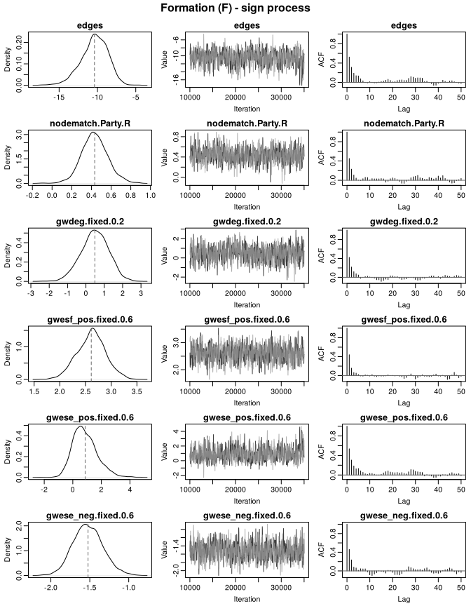

```r
plot(fit, components = "F")
```

## Interpretation

Taken at face value, the formation and persistence of positive ties both show transitivity among friends ($\text{gwesf}^+ > 0$), while negative ties whose endpoints share many enemies are unlikely to form or persist ($\text{gwese}^- < 0$). Both are in line with strong structural balance. Positive ties are also more likely between Republicans. The posterior probability that each effect is positive summarises the evidence for its direction:

```r
sapply(fit$theta, function(a) round(apply(a, 2, function(v) mean(v > 0)), 3))
```

```
#>                         F     P
#> edges               0.000 0.000
#> nodematch.Party.R   0.999 0.996
#> gwdeg.fixed.0.2     0.751 0.776
#> gwesf_pos.fixed.0.6 1.000 1.000
#> gwese_pos.fixed.0.6 0.857 0.040
#> gwese_neg.fixed.0.6 0.000 0.000
```

The next two sections show that, for this model, these estimates must be read with care.

## Goodness of fit

`bgof()` simulates the formation and persistence networks of each transition from the posterior predictive distribution. It returns the centred cumulative differences $\sum_t \{s(z'_t) - s(z_t)\}$ of the model statistics, which should be centred at zero for a well-fitting model, together with any other monitored statistics. By default the simulations are five times longer than those used for fitting, so the check is not tied to the fitting length:

```r
gf <- bgof(fit, nsim = 50, seed = 1, verbose = FALSE,
           monitor = ~ degree(0:12) + degree_neg(0:12) + triangle_signed())
gs <- summary(gf)
gs$F[c(1:6, 33:36), ]
```

```
#>                       observed       mean      2.5%      97.5% p-value
#> edges                 821.0000  1320.0800  986.5500  1641.3250    0.00
#> nodematch.Party.R     194.0000   281.5000  224.2500   335.4250    0.00
#> gwdeg.fixed.0.2       158.9383   167.0646  152.7649   170.9963    0.20
#> gwesf_pos.fixed.0.6  1403.0557  2354.3795 1716.3009  2970.3685    0.00
#> gwese_pos.fixed.0.6  1490.9141  2307.1650 1786.1258  2784.3681    0.00
#> gwese_neg.fixed.0.6  3781.0617  2274.5028  443.9927  3446.2097    0.00
#> triangle_signed+++   2505.0000  3416.2000 1790.5250  5877.0250    0.64
#> triangle_signed++-   1346.0000  8253.2600 5995.6500 10301.8750    0.00
#> triangle_signed+--  11729.0000 11454.4000 9555.9750 14087.5000    0.44
#> triangle_signed---  11514.0000  3970.1400  277.0000  7974.4000    0.00
```

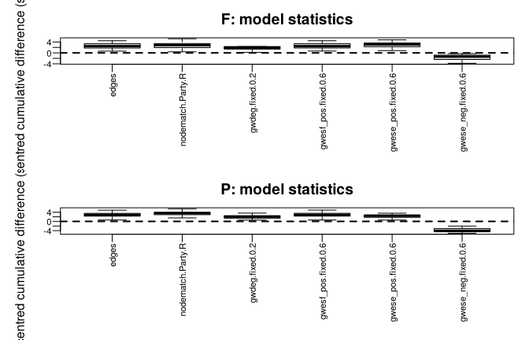

```r
plot(gf, type = "model")
```

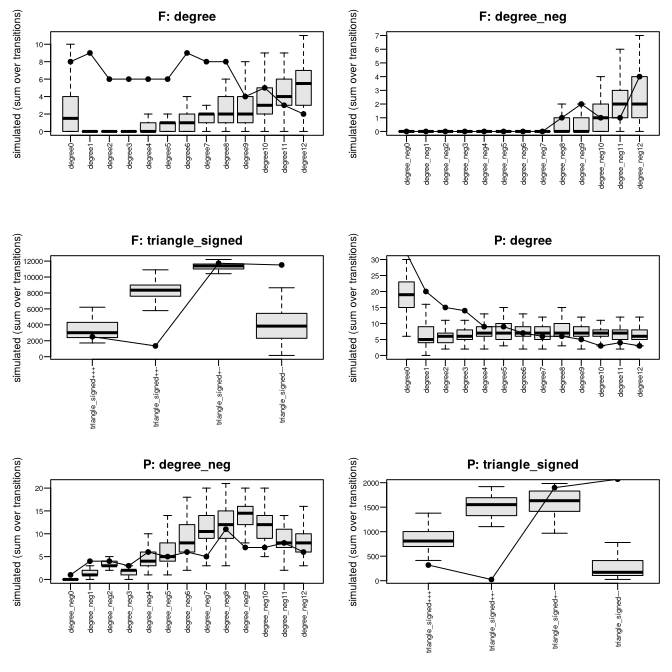

```r
plot(gf, type = "monitor")
```

The simulated formation networks have on average 1320 positive ties over the two transitions, against 821 observed, and 8253 unbalanced `++-` triangles, against 1346. The model statistics are not centred at zero. The next section shows why.

## Checking the auxiliary simulations

The approximate exchange algorithm treats the end of each auxiliary simulation, which starts at the observed network, as an exact draw from the model. `aux_diagnostics()` checks this assumption. It runs much longer simulations from the observed networks at the posterior mean and records the model statistics. In the plots, the dashed line is the observed value and the dotted vertical line the length used for fitting:

```r
dg <- aux_diagnostics(fit, visits = 50, seed = 1)
dg
```

```
#> Auxiliary simulations started at the observed networks (50 proposals per free dyad)
#> drift = (mean over the second half - value at the fitting length) / SD over the second half
#>         (SD floored at 10% of the SD of the whole trajectory)
#>
#> Component F, transition t1 (fitting used 3 proposals per free dyad)
#>                     observed at fitting length second half mean  drift
#> edges                 380.00            384.00           673.24   5.31
#> nodematch.Party.R      65.00             75.00           133.18   5.85
#> gwdeg.fixed.0.2        80.79             78.64            85.50  25.37
#> gwesf_pos.fixed.0.6   631.76            647.07          1212.20   5.73
#> gwese_pos.fixed.0.6   689.33            696.95          1185.83   7.50
#> gwese_neg.fixed.0.6  1917.67           1912.40            42.09 -24.12
#>
#> Component P, transition t1 (fitting used 3 proposals per free dyad)
#>                     observed at fitting length second half mean  drift
#> edges                 138.00            153.00           270.27  11.37
#> nodematch.Party.R      22.00             32.00            63.37   7.07
#> gwdeg.fixed.0.2        60.96             63.54            72.99   5.34
#> gwesf_pos.fixed.0.6   180.37            211.67           421.36  10.06
#> gwese_pos.fixed.0.6   188.08            222.91           275.94   5.55
#> gwese_neg.fixed.0.6   624.99            555.63           148.31 -15.11
```

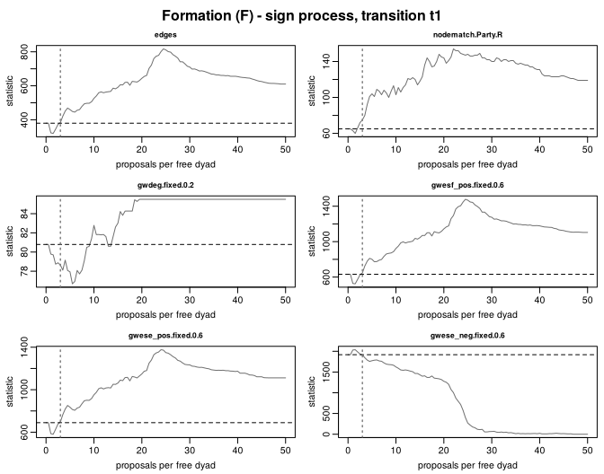

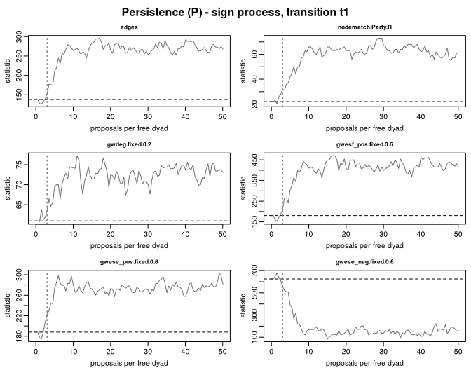

```r
plot(dg)
```

With three proposals per free dyad the simulated networks stay close to the observed ones. Longer simulations move away from them: in the first formation network, positive ties grow from 380 to about 673, and the negative ties weighted by shared enemies ($\text{gwese}^-$) fall from 1918 to about 42. All-negative triangles almost disappear, while unbalanced `++-` triangles become far more frequent than observed (see the goodness-of-fit plots). At these parameter values the model’s stationary distribution is far from the data, and the auxiliary simulations used for fitting are far from stationarity. The sampled distribution is then a local, contrastive-divergence-like approximation around the observed networks rather than the posterior of the model.

Longer auxiliary simulations (`aux.iters`, or `control.bstergm(aux.visits =)`) move the approximation towards the posterior of the model, at a cost that grows linearly. For models like this one, `aux_diagnostics()` and `bgof()` should be checked before the estimates are interpreted, and models less prone to degeneracy should be considered.

## The interaction process: binary networks

The interaction layer is a sequence of binary networks and follows an ordinary separable temporal ERGM. Formation networks contain the previous interactions, and persistence networks are contained in them. It is fitted with `bstergm()` and ordinary ergm terms. `bstergm()` accepts a signed series, whose interactions it uses, or any list of binary adjacency matrices or `network` objects, which `network_series()` converts:

```r
fit_x <- bstergm(~ edges + nodematch("Party", diff = TRUE, levels = "R") +
                   gwdegree(0.2, fixed = TRUE) + gwesp(0.6, fixed = TRUE),
                 data = senate, iters = 35000,
                 burn.in = 10000, thin = 25, n_chains = 2, cores = 2, seed = 2025,
                 prior.mean = c(-1, 0, 0, 0), prior.sigma = 25)
```

```r
summary(fit_x)
```

```
#> Posterior summary (AMH, 35000 iterations, 10000 burn-in, thin 25)
#>
#> Formation (F) - binary network
#>   chains: 2 | acceptance: 0.227 0.227
#>                     Mean    SD Naive SE Time-series SE   2.5%    50%  97.5%
#> edges              1.426 4.325    0.097          0.100 -7.291  1.410  9.451
#> nodematch.Party.R -0.124 0.102    0.002          0.003 -0.323 -0.125  0.075
#> gwdeg.fixed.0.2    0.081 5.038    0.113          0.128 -9.476  0.037 10.047
#> gwesp.fixed.0.6   -1.220 2.374    0.053          0.055 -5.614 -1.208  3.586
#>                        ESS  Rhat
#> edges             1873.846 1.000
#> nodematch.Party.R 1589.867 1.002
#> gwdeg.fixed.0.2   1539.744 1.000
#> gwesp.fixed.0.6   1873.980 1.000
#>
#> Persistence (P) - binary network
#>   chains: 2 | acceptance: 0.164 0.168
#>                     Mean    SD Naive SE Time-series SE   2.5%    50%  97.5%
#> edges              0.184 0.340    0.008          0.009 -0.530  0.198  0.823
#> nodematch.Party.R -0.394 0.130    0.003          0.004 -0.638 -0.397 -0.129
#> gwdeg.fixed.0.2   -2.218 3.191    0.071          0.088 -8.344 -2.378  4.568
#> gwesp.fixed.0.6    0.270 0.163    0.004          0.004 -0.030  0.264  0.617
#>                        ESS  Rhat
#> edges             1355.801 1.014
#> nodematch.Party.R 1221.122 1.000
#> gwdeg.fixed.0.2   1323.610 1.002
#> gwesp.fixed.0.6   1365.571 1.014
#>
#> Total time: 30.7min
```

Some of these posteriors are as wide as the prior. In these dense networks the pairs that could start interacting already have many shared partners, and all senators have high degrees. On the formation sample space the change statistic of `gwesp(0.6)` is therefore almost constant and that of `gwdegree(0.2)` is zero, so these parameters are not identified separately from `edges` (`ergmMPLE()` warns about the linear dependence). The draws of `edges` and `gwesp` are perfectly correlated:

```r
round(cor(as.matrix(as.mcmc.list(fit_x, components = "F"))), 2)
```

```
#>                   edges nodematch.Party.R gwdeg.fixed.0.2 gwesp.fixed.0.6
#> edges              1.00              0.00           -0.01           -1.00
#> nodematch.Party.R  0.00              1.00            0.01           -0.01
#> gwdeg.fixed.0.2   -0.01              0.01            1.00            0.01
#> gwesp.fixed.0.6   -1.00             -0.01            0.01            1.00
```

Their combination, which gives the probability that a new interaction forms, is well determined, so predictions are not affected, but the separate parameters should not be interpreted. Dropping `gwdegree()`, or using terms whose change statistics vary on the sample space, avoids the problem.

## Simulation and forecasting

`simulate()` returns posterior predictive replicates of the observed transitions: the formation and persistence networks and the signed networks they imply at each time point, given the observed interactions:

```r
sims <- simulate(fit, nsim = 1, seed = 2)
sapply(sims[[1]]$y, signed_triad_census)
```

```
#>     S100 S101
#> +++ 1271 1700
#> ++- 2157 3042
#> +-- 1821 2435
#> ---  594  770
```

`predict()` forecasts future networks. A `bstergm()` fit alone forecasts binary networks:

```r
summary(predict(fit_x, horizon = 1, nsim = 20, seed = 3, verbose = FALSE))
```

```
#> Forecast T+1:
#>           start   mean   2.5%  97.5%
#> ties       1173 1149.8 1129.0 1183.2
#> triangles  7947 6129.0 5707.5 6690.5
```

With a `bstergm_sign()` fit of the signs as well, it forecasts signed networks. At each step it simulates the formation and persistence of interactions, then the signs of the new and persisting interactions:

```r
fc <- predict(fit, fit_x, horizon = 1, nsim = 20, seed = 3, verbose = FALSE)
summary(fc)
```

```
#> Forecast T+1:
#>          start   mean   2.5%  97.5%
#> positive   363  476.8  363.2  639.2
#> negative   810  673.0  511.0  800.5
#> ties      1173 1149.8 1129.0 1183.2
#> +++       1119  769.0  370.9 1487.8
#> ++-        114 1737.0 1276.3 2357.9
#> +--       3521 2300.3 1791.0 2660.4
#> ---       3193 1322.8  538.7 2144.2
```

Here the forecasts inherit the drift of the sign model described above.

## Further options

- **Time-varying covariates**: `formula` can be a list with one formula per transition. Lagged dyadic covariates of the previous network are available as `edgecov("lag.pos")`, `edgecov("lag.neg")` and `edgecov("lag.active")`.
- **Adaptive direction sampling**: `method = "ads"` (or `aea_ads()`) runs a population of interacting chains; `init = "ads"` uses it only to find starting values for adaptive Metropolis-Hastings.
- **Priors and starting values**: `prior.mean`, `prior.sigma` and `init` accept component-specific values as `list(F = ..., P = ...)`. A previous fit can be passed as `init` to continue its chains.
- **Static signed ERGMs**: networks built by `as_signed_network()` can be used directly with `ergm::ergm()` and the constraint `~active_signs`.
- **Version 0.1 code**: `aea_amh()`, `aea_ads()` and `simulate_stats()` accept the arguments of the first version of the package (then called B2Lstergm), including multilayer formulas with the constraint term `L(~edges, active)`. That term is detected and dropped automatically, and the formula is translated into the equivalent native terms when possible.

## References

Caimo, A. and Friel, N. (2011). Bayesian inference for exponential random graph models. *Social Networks*, 33(1), 41–55.

Caimo, A. and Gollini, I. (2025). Separable models for dynamic signed networks. arXiv:2505.07669.

Haario, H., Saksman, E. and Tamminen, J. (2001). An adaptive Metropolis algorithm. *Bernoulli*, 7(2), 223–242.

Krivitsky, P. N. and Handcock, M. S. (2014). A separable model for dynamic networks. *Journal of the Royal Statistical Society B*, 76(1), 29–46.

Neal, Z. P. (2020). A sign of the times? Weak and strong polarization in the U.S. Congress, 1973–2016. *Social Networks*, 60, 103–112.